# EDA_Correlations

```python
import pandas as pd
import matplotlib.pyplot as plt
import seaborn as sns
import numpy as np
#import unidecode  ##To delete mark accents
%matplotlib inline
import pandas as pd
from dython.nominal import associations
```

```python
data = pd.read_excel("data_eda.xlsx")
data.drop('Unnamed: 0', axis = 1, inplace = True)
```

```python
data.columns
data2 = data[["CARGO_CORPORATIVO","LINEA_SERVICIO","NRO_HIJOS","JORNADA_LABORAL_MES","EDAD","GENERACION","GENERO","REGIONAL","TIPO_CONTRATO","FONDEX","NEGOCIO","NIVEL_RIESGO","CAUSAL_FIN_CONTRATO","ESTRATO","NIVEL_ESTUDIO","ESTADO_CIVIL","INACTIVO","ACTIVO","ALTA","SECTOR"]]
'COD_CIUDAD_LABOR', 'FECHA_NACIMIENTO'
```

```
('COD_CIUDAD_LABOR', 'FECHA_NACIMIENTO')
```

```python
incapacidades = pd.read_excel("incapacidades_eda.xlsx")
incapacidades.drop("Unnamed: 0", axis=1, inplace = True)
```

```python
reportes_AT = pd.read_csv("reportes_AT.csv", sep = ',', encoding= 'latin')
reportes_AT["Se_accidento"] = 1
```

```python
reportes_AT=reportes_AT[reportes_AT["IDENTIFICADOR"].notnull()]
list_drop_AT=['Unnamed: 0', 'CIUDAD', 'ZONA']
reportes_AT.drop(list_drop_AT, axis=1, inplace = True)
reportes_AT.columns
```

```
Index(['IDENTIFICADOR', 'Se_accidento'], dtype='object')
```

```python
from dython.nominal import identify_nominal_columns
categorical_features=identify_nominal_columns(data)
categorical_features
```

```
['IDENTIFICADOR',
 'CIUDAD_RESIDENCIA',
 'CIUDAD_LABOR',
 'GENERACION',
 'GENERO',
 'REGIONAL',
 'TIPO_CONTRATO',
 'FONDEX',
 'NEGOCIO',
 'LINEA_SERVICIO',
 'EPS_COD',
 'EPS',
 'COD_CARGO',
 'CARGO',
 'CARGO_CORPORATIVO',
 'CAUSAL_FIN_CONTRATO',
 'ESTRATO',
 'NIVEL_ESTUDIO',
 'ESTADO_CIVIL',
 'SECTOR']
```

```python
data.ESTADO_CIVIL.replace('CASADO', 'CASADO/A', inplace = True)
data.ESTADO_CIVIL.replace('NINGUNO', 'SIN_DEFINIR', inplace = True)
```

```python
data.NIVEL_RIESGO.replace('NIVEL 1  DE RIESGO 0.522 %', 1, inplace = True)
data.NIVEL_RIESGO.replace('NIVEL 2  DE RIESGO 1.044 %', 2, inplace = True)
data.NIVEL_RIESGO.replace('NIVEL 3  DE RIESGO  2.436 %', 3, inplace = True)
data.NIVEL_RIESGO.replace('NIVEL 4  DE RIESGO  4.35   %', 4, inplace = True)
data.NIVEL_RIESGO.replace('NIVEL 5  DE RIESGO  6.96  %', 5, inplace = True)
```

```python
def values_corr (dataframe):
    th = 0.5
    cont = 0
    for fila in range(dataframe.shape[0]):
        for columna in range(dataframe.shape[1]):
            if np.abs(dataframe.iloc[fila, columna]) > th and  fila != columna:
                cont += 1
                print('{} : th = {} for variables {} and {}'.format(cont, round(dataframe.iloc[fila, columna],2), dataframe.columns[fila], dataframe.columns[columna]))
```

```python
#Barrido de relaciones sin categoricas nominales De resto estan todas si te da coges todas estas para verlas de una vez. si no
# versión reducida: estas columnas que son las más relevantes:
# GENERACION', 'GENERO', 'REGIONAL', 'TIPO_CONTRATO', 'NEGOCIO', 'NIVEL_RIESGO', 'LINEA_SERVICIO','ESTRATO','NIVEL_ESTUDIO','ESTADO_CIVIL', 'SECTOR'
#data2 = data[["CARGO_CORPORATIVO","LINEA_SERVICIO","NRO_HIJOS","JORNADA_LABORAL_MES","EDAD","GENERACION","GENERO","REGIONAL","TIPO_CONTRATO","FONDEX","NEGOCIO","NIVEL_RIESGO","CAUSAL_FIN_CONTRATO","ESTRATO","NIVEL_ESTUDIO","ESTADO_CIVIL","INACTIVO","ACTIVO","ALTA","SECTOR"]]
data2 = data[['COD_CIUDAD_LABOR', 'CIUDAD_RESIDENCIA', 'NRO_HIJOS',
       'CIUDAD_LABOR', 'JORNADA_LABORAL_MES',  'EDAD',
       'GENERACION', 'GENERO', 'COD_CLIENTE', 'CODIGO_LINEA', 'REGIONAL',
       'TIPO_CONTRATO', 'OT', 'FONDEX', 'NEGOCIO', 'NIVEL_RIESGO', 'LINEA_SERVICIO', 'EPS_COD', 'EPS',
       'COD_CARGO', 'CARGO', 'CARGO_CORPORATIVO', 'CAUSAL_FIN_CONTRATO',
       'ESTRATO', 'NIVEL_ESTUDIO', 'ESTADO_CIVIL', 'INACTIVO',
       'ACTIVO', 'ALTA', 'SECTOR']]
```

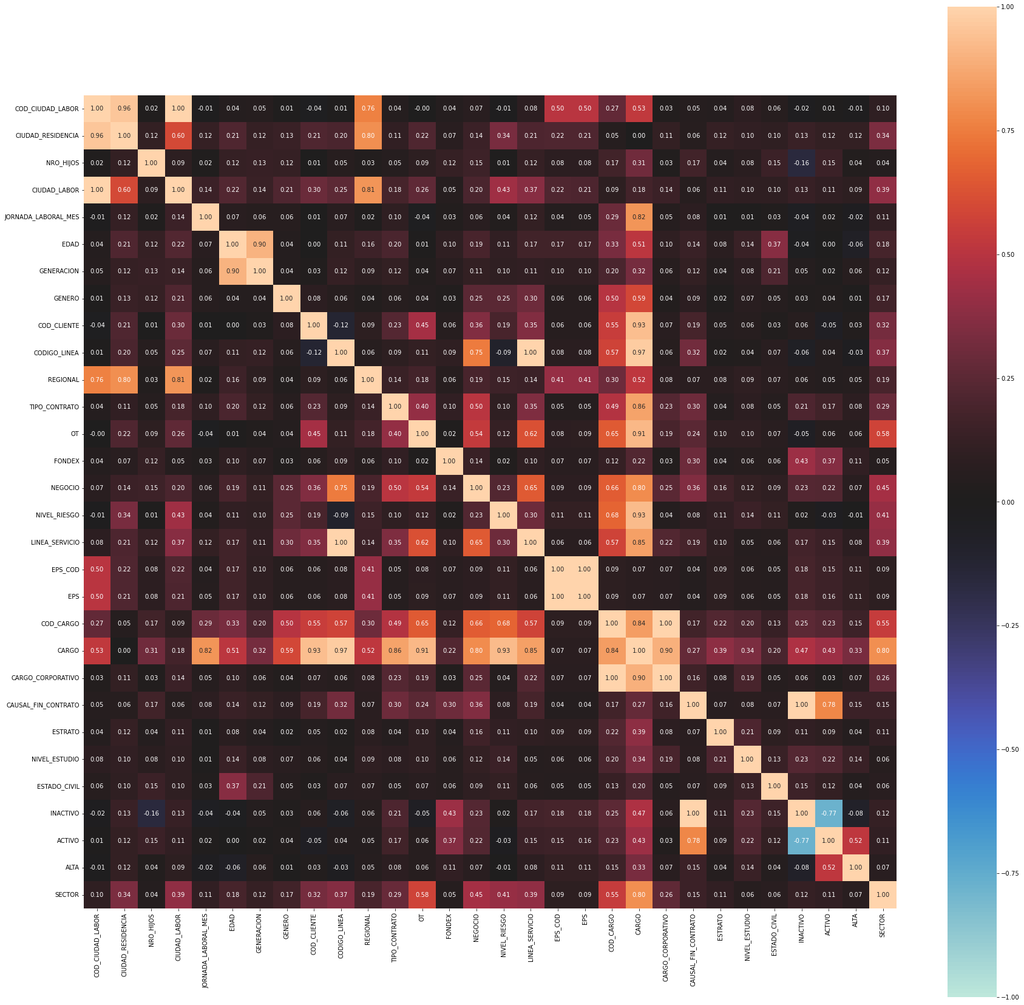

```python
#Correlación de variables apra Data (colaboradores activos)
associations_data = associations(data2, nominal_columns='auto', numerical_columns=None, mark_columns=False, nom_nom_assoc='cramer', num_num_assoc='pearson', ax=None, figsize=(30,30), annot=True, fmt='.2f', cmap=None, sv_color='silver', cbar=True, vmax=1.0, vmin=None, plot=True, compute_only=False, clustering=False, title=None, filename=None)
```

```python
corr_data = pd.DataFrame(list(associations_data.values())[0])
```

NEGOCIO relations and LINEA_DE_SERVICIO, it is because why the LINEA_DE_SERVICIO are the services provided to businesses (customers and their categorization). GENERACION and EDAD are closely related and GENERACION are slices of age periods. The NEGOCIO and the TIPO_DE_CONTRATO are related variables since the business (focus of types of services provided) change the type of contract used. INACTIVO and FONDEX is an unexpected variable and it is proposed to know their relationship (Insight). The NEGOCIO and the SECTOR have a relationship and it is explained that the business brings together target market niches (Sectors). If there is cause for the contract, it must be inactive because the relationship here is completely linear. ACTIVO and REGISTRO are related in that the first month of the collaborator, if he is withdrawn, this variable would also appear. It is true if the collaborator is withdrawn before the month. The service line and the sector have a close operational relationship, so this correlation coefficient between the two is clear, as with NEGOCIO, there is also a relationship between the level of risk and the sector, which is a very important finding.

```python
#Para Incapacidades
#Barrido de relaciones sin categoricas nominales De resto estan todas
#incapacidades2 = incapacidades[["CONCEPTO","DIAS","TIPO_INCAPACIDAD","ESTADO_INC","ESTADO_PAGO"]]
incapacidades2 = incapacidades[['COD_INCAPACIDAD', 'CONCEPTO',
       'CONTINGENCIA', 'DIAS', 'TIPO_INCAPACIDAD',
       'COD_ORIGEN', 'COD_DIAGNOSTICO', 'DIAG_DESCRIPCION', 'VALOR_IBC',
       'VALOR_PAGADO', 'ESTADO_INC', 'ESTADO_PAGO', 'ENTIDAD',
       'NOMBRE_ENTIDAD', 'CLASE_NOMINA', 'NOMBRE IPS - ARL']]
```